# Projection predictive feature selection for the MCED GAGome score

Sinisa Bratulic

14 November, 2022

# 1 Introduction

This report accompanies the article ‘Noninvasive detection of any-stage cancer using free glycosaminoglycans’.

It demonstrates the use of projection predictive feature selection to create a model for predicting the probability of cancer based on free plasma and urine GAGomes. At its core, the procedure starts with fitting a reference model (Bayesian logistic regression model) using all the available GAGome feature, and then using projection predictive feature selection to reduce the number of features to the most informative ones.

Because of the sensitive nature of clinical data used in the article, this demonstration is limited to a synthetic dataset that has similar characteristics as the real data.

# 2 Setup

Load libraries that we use throught the analysis.

```r
library(tidyverse)
library(rstanarm)
library(projpred)
library(tidybayes)
library(broom.mixed)
library(pROC)
library(patchwork)
library(cutpointr)
library(gt)
library(coda)
options(mc.cores = parallel::detectCores())
```

Load the synthetic data set.

```r
data_synth <- read.delim("data/synthetic.csv", sep = "\t") %>%
  mutate(y = factor(y))
```

```r
str(data_synth)
```

```
## 'data.frame':    523 obs. of  24 variables:
##  $ y                  : Factor w/ 2 levels "0","1": 2 1 1 1 2 1 1 1 2 2 ...
##  $ ug.ml_CS_plasma    : num  -1.121 -0.428 0.264 -0.751 1.892 ...
##  $ X0s_CS_plasma_conc : num  -2.029 -0.432 0.873 -0.321 1.724 ...
##  $ X4s_CS_plasma_conc : num  -0.0858 -0.3183 -0.292 -0.9056 1.5264 ...
##  $ X0s_CS_plasma      : num  -2.9943 -0.1715 1.0495 0.768 0.0164 ...
##  $ X4s_CS_plasma      : num  2.9975 0.1673 -1.0166 -0.7337 -0.0478 ...
##  $ X4s.0s_CS_plasma   : num  5.7622 -0.0188 -0.946 -0.761 -0.2022 ...
##  $ ug.ml_CS_urine     : num  -0.0118 -0.3411 0.4948 -0.499 1.0432 ...
##  $ ug.ml_HS_urine     : num  -0.0798 -0.574 -0.2237 -0.6134 5.5254 ...
##  $ X0s_CS_urine_conc  : num  -0.1251 -0.251 0.6561 -0.0861 -0.3284 ...
##  $ X6s_CS_urine_conc  : num  0.415 -0.538 0.789 -0.637 0.906 ...
##  $ X4s_CS_urine_conc  : num  -0.0816 -0.2475 0.1214 -0.6251 1.9641 ...
##  $ X2s6s_CS_urine_conc: num  -0.00382 -0.54254 0.68429 -0.68646 2.62514 ...
##  $ Ns_HS_urine_conc   : num  -0.18989 -0.75266 0.00285 -0.68975 5.35068 ...
##  $ X0s_HS_urine_conc  : num  -0.0529 -0.7737 -0.17 -0.7384 6.1385 ...
##  $ X0s_CS_urine       : num  -0.1953 -0.0543 0.773 0.945 -1.2555 ...
##  $ X6s_CS_urine       : num  0.4 -0.5 -0.165 -0.24 -0.781 ...
##  $ X4s_CS_urine       : num  -0.134 0.523 -0.852 -0.934 2.537 ...
##  $ X2s6s_CS_urine     : num  -0.0258 -0.4115 0.1556 -0.4464 1.2228 ...
##  $ Ns_HS_urine        : num  -0.248 -1.801 1.506 0.197 -0.203 ...
##  $ X0s_HS_urine       : num  0.156 -1.759 0.509 -0.222 -0.216 ...
##  $ Charge_CS_urine    : num  0.2034 0.0704 -0.7834 -0.9793 1.2373 ...
##  $ X6s.0s_CS_urine    : num  -0.182 -0.468 -0.618 -0.661 0.519 ...
##  $ X4s.0s_CS_urine    : num  -0.311 -0.263 -0.745 -0.787 2.48 ...
```

The data contain synthetic (standardized) GAGome values and associated ‘outcome’ variable stored in the y:

- y is encoded as a binary variable (0 is control, 1 is cancer)
- Columns that end with `_conc` suffix contain standardized values of measured absolute GAGome concentrations in ug/mL.
- Columns with the same name, but without the suffix contains standardized values of the mass fraction percentage.
- Columns that start with `ug.ml_` prefix contain standardized values of the total concentrations of a GAG fraction (e.g. `ug.ml_CS_urine` is a sum of all CS GAGs in urine).
- Ratio features contain `.` symbols (e.g. `X4s.0s_CS_urine` is ratio of 4S CS and 0S CS in urine).

The number of cases vs controls in the dataset:

```r
table(data_synth$y)
```

```
##
##   0   1
## 334 189
```

# 3 Fitting a reference model

First, we will fit the reference Bayesian logistic model. We will build a combined plasma and urine model, using all GAGome features as predictors.

We will set up priors for individual coefficients and the intercept as a student-t distribution with 7 degrees of freedom.

```r
SEED = 7
set.seed(SEED)

t_prior <- student_t(df = 7, location = 0, scale = 2.5)

(GAGform <- as.formula(paste("y", paste(colnames(data_synth)[-1], collapse=" + "), sep=" ~ ")))
```

```
## y ~ ug.ml_CS_plasma + X0s_CS_plasma_conc + X4s_CS_plasma_conc +
##     X0s_CS_plasma + X4s_CS_plasma + X4s.0s_CS_plasma + ug.ml_CS_urine +
##     ug.ml_HS_urine + X0s_CS_urine_conc + X6s_CS_urine_conc +
##     X4s_CS_urine_conc + X2s6s_CS_urine_conc + Ns_HS_urine_conc +
##     X0s_HS_urine_conc + X0s_CS_urine + X6s_CS_urine + X4s_CS_urine +
##     X2s6s_CS_urine + Ns_HS_urine + X0s_HS_urine + Charge_CS_urine +
##     X6s.0s_CS_urine + X4s.0s_CS_urine
```

We will fit the logistic model using `rstanarm` function `stan_glm`.

```r
filename <- "models/stan_glm_t_synthdata.rds" # save the model to avoid refitting
if (!file.exists(filename)){
  mod_sim <- stan_glm(formula = GAGform,
                      data = data_synth,
                      family = binomial(link = "logit"),
                      prior = t_prior,
                      prior_intercept = t_prior,
                      QR = TRUE,
                      seed = SEED,
                      adapt_delta = 0.99,
                      iter = 4000,
                      cores = 4,
                      chains = 4)
  saveRDS(mod_sim, file = filename)
} else {
  mod_sim<- readRDS(filename)
}
```

## 3.1 Check model diagnostics

We can check the fitted model diagnostics in several ways.

We can look at individual trace plots (not run here).

```r
plot(mod_sim, "trace") #not run
run <- run_mcmc(model = m, stanfit = TRUE)
```

We can check the fit diagnostics (Rhat) and if the fitted model is compatible with the observed data using posterior predictive checks.

```r
summary(mod_sim)
```

```
##
## Model Info:
##  function:     stan_glm
##  family:       binomial [logit]
##  formula:      y ~ ug.ml_CS_plasma + X0s_CS_plasma_conc + X4s_CS_plasma_conc +
##     X0s_CS_plasma + X4s_CS_plasma + X4s.0s_CS_plasma + ug.ml_CS_urine +
##     ug.ml_HS_urine + X0s_CS_urine_conc + X6s_CS_urine_conc +
##     X4s_CS_urine_conc + X2s6s_CS_urine_conc + Ns_HS_urine_conc +
##     X0s_HS_urine_conc + X0s_CS_urine + X6s_CS_urine + X4s_CS_urine +
##     X2s6s_CS_urine + Ns_HS_urine + X0s_HS_urine + Charge_CS_urine +
##     X6s.0s_CS_urine + X4s.0s_CS_urine
##  algorithm:    sampling
##  sample:       8000 (posterior sample size)
##  priors:       see help('prior_summary')
##  observations: 523
##  predictors:   24
##
## Estimates:
##                       mean   sd    10%   50%   90%
## (Intercept)          -0.8    0.2  -1.0  -0.8  -0.5
## ug.ml_CS_plasma      41.2   29.2   5.8  38.9  79.2
## X0s_CS_plasma_conc  -18.7   15.3 -38.8 -17.5  -0.2
## X4s_CS_plasma_conc  -27.1   18.7 -51.5 -25.7  -4.7
## X0s_CS_plasma        11.9    9.2   0.9  10.9  24.0
## X4s_CS_plasma        12.3    9.2   1.4  11.4  24.2
## X4s.0s_CS_plasma      2.2    0.8   1.2   2.1   3.2
## ug.ml_CS_urine      -47.8   11.5 -63.2 -47.3 -33.3
## ug.ml_HS_urine        2.1    1.2   0.6   2.0   3.6
## X0s_CS_urine_conc    21.2    5.2  14.6  21.0  28.2
## X6s_CS_urine_conc     9.3    2.3   6.4   9.2  12.3
## X4s_CS_urine_conc    24.9    5.7  17.7  24.7  32.5
## X2s6s_CS_urine_conc  -0.1    0.6  -0.9  -0.2   0.6
## Ns_HS_urine_conc     -0.4    1.0  -1.6  -0.4   0.8
## X0s_HS_urine_conc     0.2    0.9  -0.9   0.2   1.3
## X0s_CS_urine        -11.5    8.5 -22.5 -11.4  -0.6
## X6s_CS_urine         -7.0    1.8  -9.3  -6.9  -4.7
## X4s_CS_urine         -7.2    1.9  -9.6  -7.1  -4.9
## X2s6s_CS_urine       -0.6    0.4  -1.1  -0.5   0.0
## Ns_HS_urine          -0.8    0.2  -1.1  -0.8  -0.5
## X0s_HS_urine          0.5    0.2   0.2   0.5   0.8
```

[output cut: 25 more lines]

```
## Ns_HS_urine_conc    0.0  1.0   7401
## X0s_HS_urine_conc   0.0  1.0   6689
## X0s_CS_urine        0.1  1.0  12138
## X6s_CS_urine        0.0  1.0  10175
## X4s_CS_urine        0.0  1.0   9934
## X2s6s_CS_urine      0.0  1.0   9089
## Ns_HS_urine         0.0  1.0   9009
## X0s_HS_urine        0.0  1.0   9172
## Charge_CS_urine     0.1  1.0  13043
## X6s.0s_CS_urine     0.0  1.0   9974
## X4s.0s_CS_urine     0.0  1.0  10101
## mean_PPD            0.0  1.0   9608
## log-posterior       0.1  1.0   3100
##
## For each parameter, mcse is Monte Carlo standard error, n_eff is a crude measure of effective sample size, and Rhat is the potential scale reduction factor on split chains (at convergence Rhat=1).
```

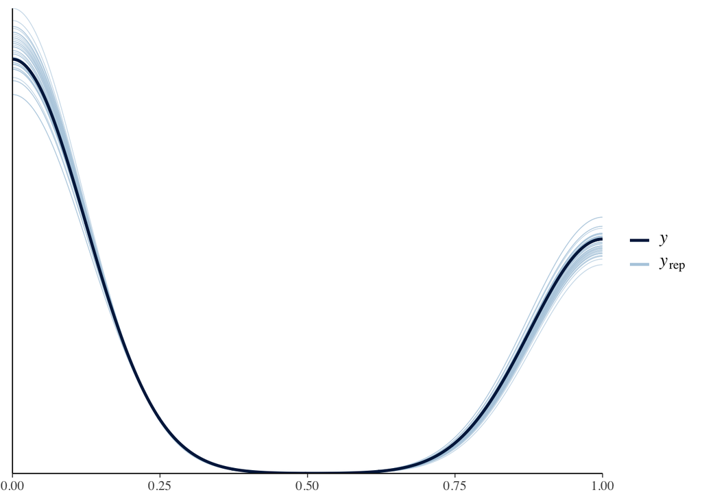

```r
pp_check(mod_sim)
```

Let’s plot reference model estimates (with 95% credible intervals)

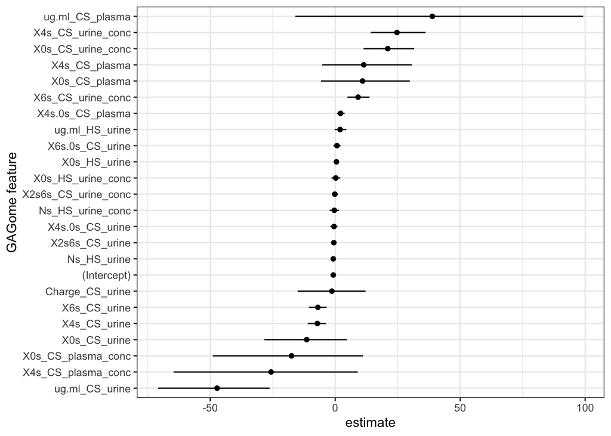

```r
tidy(mod_sim,
     robust = T,
     conf.int = T,
     conf.level = 0.95,
     conf.method = "HPD") %>%
  ggplot(aes(x = estimate, y = fct_reorder(term, estimate))) +
  geom_point() +
  geom_linerange(aes(xmin = conf.low, xmax = conf.high)) +
  theme_bw() +
  scale_color_brewer(palette =
                       "Set1") +
  ylab("GAGome feature")
```

# 4 Variable selection

We will use projection predictive variable selection to reduce the number predictors to the most informative ones. To do this, we will use the `projpred` function `cv_varsel`. This will find the best submodel for each individual submodel size (submodel size refers to the number of predictors used). The function will carry out the forward search and leave-one-out cross-validation to find the best submodel for each size.

NOTE: depending on your hardware, this procedure can take several hours. We have run the code and stored a variable selection object as a binary file.

```r
n <- dim(data_synth)[1]

# save the var sel object to avoid refitting (this can take a very long time)

filenamevarsel <- "models/stan_glm_t_synth_varsel.rds"

if (!file.exists(filenamevarsel)){
  refmodel <- get_refmodel(mod_sim)
  varselF <- cv_varsel(refmodel,
                       method = 'forward',
                       cv_method = "LOO",
                       cores = 8,
                       seed = 11)
  saveRDS(varselF, file = filenamevarsel)
} else{
  varselF <- readRDS(filenamevarsel)
}
```

Once the projection predictive variable selection is complete, we can check the variable importance, as well the the suggestted model size.

```r
(vif <- solution_terms(varselF))
```

```
##  [1] "ug.ml_CS_plasma"     "X0s_HS_urine_conc"   "Ns_HS_urine"
##  [4] "X4s.0s_CS_plasma"    "X0s_HS_urine"        "X0s_CS_plasma_conc"
##  [7] "X0s_CS_urine_conc"   "ug.ml_HS_urine"      "X2s6s_CS_urine_conc"
## [10] "X2s6s_CS_urine"      "X4s_CS_urine_conc"   "X4s_CS_urine"
## [13] "ug.ml_CS_urine"      "X6s_CS_urine_conc"   "Ns_HS_urine_conc"
## [16] "X6s_CS_urine"        "X0s_CS_urine"        "X4s_CS_plasma_conc"
## [19] "X6s.0s_CS_urine"
```

```r
message("Suggested model size")
```

```
## Suggested model size
```

```r
(size_suggested = suggest_size(varselF, stat = "elpd"))
```

```
## [1] 17
```

The default suggested size is 17 variables. The same procedure with the real manuscript data resulted in a submodel with 14 GAGome features ( the combined GAGome score in the manuscript).

We will compare the performance of submodels with different sizes using different metrics (blue for the default suggested size and red for the manuscript model size).

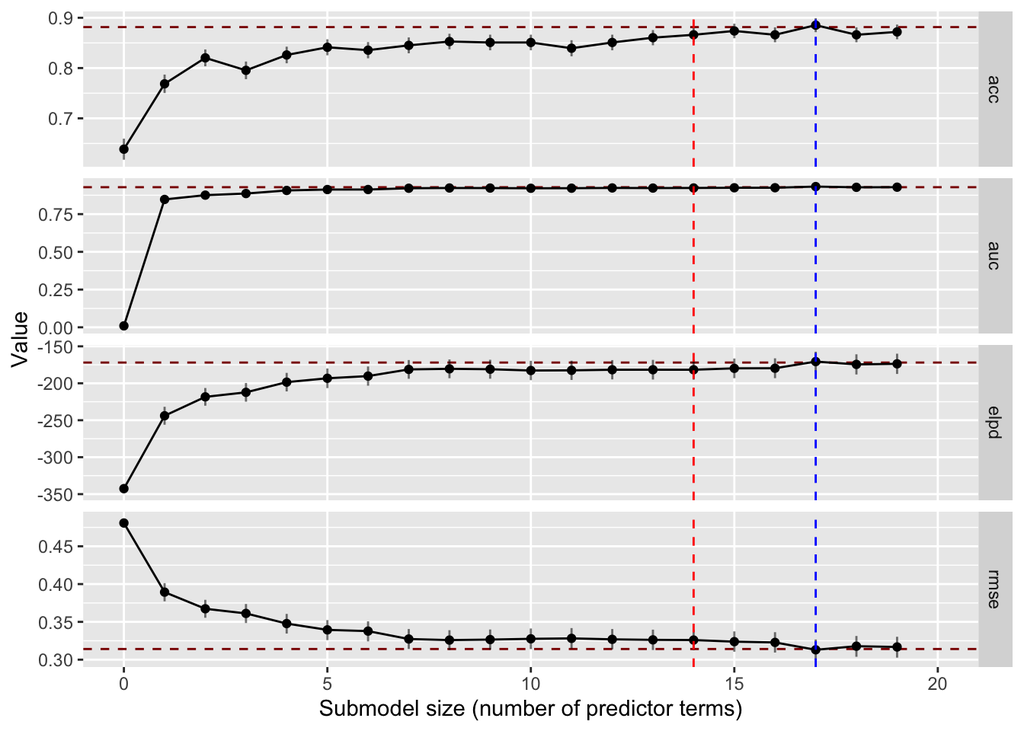

```r
manuscript_model_size = 14

plot(varselF, stats = c("elpd", "acc", "auc", "rmse")) +
  geom_vline(xintercept = size_suggested, color = "blue", linetype = "dashed") +
  geom_vline(xintercept = manuscript_model_size, color = "red", linetype = "dashed")
```

We see that the accuracy, ELPD and RMSE suggest only a small difference between the models, while the AUC is almost identical.

# 5 Projection

Given the above result, we will perform projection of the reference model’s posterior onto submodels with 14 features, to match the model size in the manuscript.

```r
filenameproj <- "models/stan_proj_synth_ms.rds"
if (!file.exists(filenameproj)){
  proj<- project(varselF,
                 nterms = manuscript_model_size,
                 seed = SEED)
  saveRDS(proj, file = filenameproj)

} else{
  proj <- readRDS(filenameproj)
}
```

## 5.1 Projected model parameters

We will plot the distributions of the coefficient values for the predictors (GAGome features) in the projected submodel.

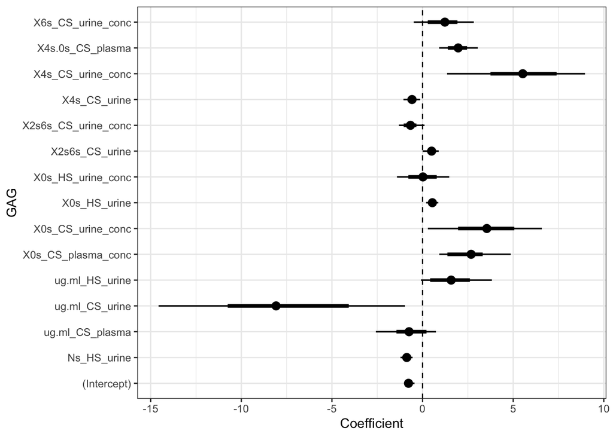

```r
as_tibble(as.matrix(proj)) %>% rowid_to_column() %>%
  pivot_longer(cols = -rowid) %>%
  ggplot(aes(x= value, y = name, ordered = T)) +
  geom_vline(xintercept = 0, linetype ="dashed")+
  ggdist::stat_pointinterval(point_interval = median_hdci,
                             position = position_dodge()) +
  xlab("Coefficient") +
  ylab("GAG") +
  theme_bw()+
  scale_color_brewer(palette = "Set1")
```

# 6 Prediction

Finally, we will calculate the linear predictors based on the submodel using the `proj_linpred` function. We use `integrated = TRUE` to average over the projected posterior draws. We use `transform = FALSE` to keep the prediction on the log-odds scale

```r
predC<- proj_linpred(proj,
                     newdata = data_synth,
                     integrated = TRUE,
                     transform = FALSE
)
```

We will add the predictions (GAGome scores) to the original data frame.

```r
data_synth$GAGscore <- predC$pred[1,]
```

# 7 Performance

Now we can check the GAGome score performance metrics: plot ROC curve, plot classification and calculate metrics (sensitivity at 98% specificity)

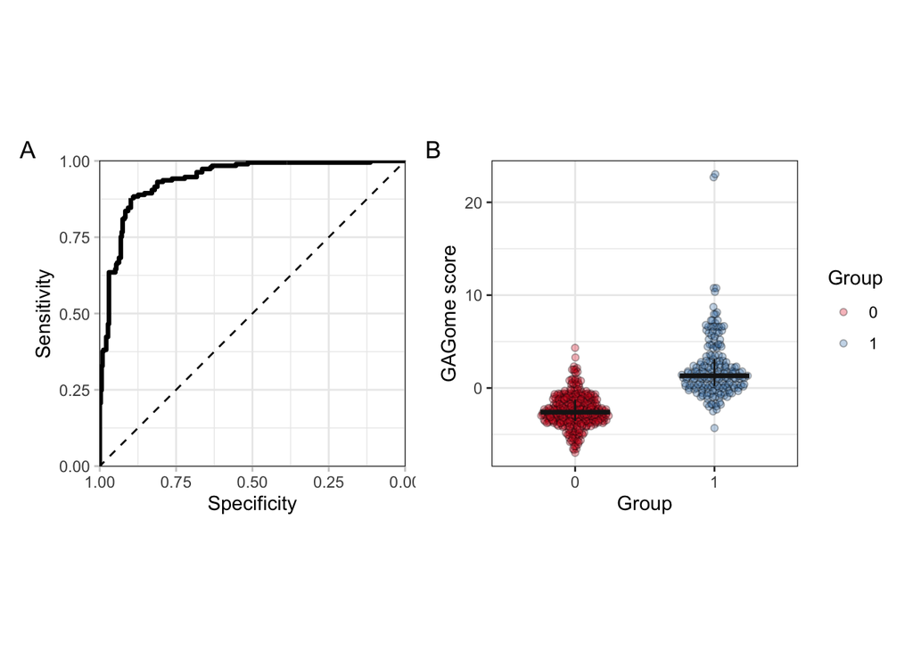

```r
classification_plot <- data_synth %>%
  ggplot(aes(x = y, y =  GAGscore)) +
  ggbeeswarm::geom_quasirandom(aes(fill = y),
                               shape = 21,
                               size = 1.5, width = 0.25,
                               alpha = 0.3
  ) +
  stat_summary(fun = median,
               geom = "crossbar", width = 0.5, color = "grey10") +
  stat_summary(fun.min = function(z) { quantile(z,0.25) },
               fun.max =function(z) { quantile(z,0.75) },
               geom = "linerange", color = "grey10") +
  theme_bw() +
  scale_fill_brewer("Group", palette = "Set1") +
  ylab("GAGome score") +
  xlab("Group")

roc_score <- pROC::roc(data_synth$y, data_synth$GAGscore)
roc_plot <- pROC::ggroc(roc_score, size = 1.2) +
  geom_abline(slope = 1, intercept = 1, linetype = "dashed")+
  theme_minimal()+
  scale_x_reverse(name = "Specificity",limits = c(1,0), expand = c(0.001,0.001)) +
  scale_y_continuous(name = "Sensitivity", limits = c(0,1),  expand = c(0.001, 0.001)) +
  theme_bw() +
  theme(axis.ticks = element_line(color = "grey80"),
        legend.position = "bottom") +
  coord_equal()+
  theme(legend.position = c(0.5, 0.2),
        legend.title = element_text(size = 14),
        legend.text = element_text(size = 14))

roc_plot + classification_plot + patchwork::plot_annotation(tag_levels = c('A'))
```

```r
cpo <- cutpointr(data_synth, GAGscore,y,
                 method = maximize_metric,
                 metric = metric_constrain,
                 main_metric = sensitivity,
                 suffix = "_constrained",
                 constrain_metric = specificity,
                 min_constrain = 0.98)
```

```
## Assuming the positive class is 1
```

```
## Assuming the positive class has higher x values
```

```r
cpo[,c(2,4,6:10)] %>%
  gt() %>%
  fmt_percent(columns = matches("sens|spec")) %>%
  fmt_number(columns = "AUC", decimals = 2)
```

| optimal_cutpoint | sensitivity_constrained | sensitivity | specificity | AUC | pos_class | neg_class |
| --- | --- | --- | --- | --- | --- | --- |
| 2.007879 | 38.10% | 38.10% | 98.80% | 0.94 | 1 | 0 |

The GAGome score achieves 38.1% sensitivity at 98% specificity for predicting the presence of cancer..